# Food at College

```r
# From your file menu (at the top of R-Studio) select:
# "Session -> Set working directory -> To source file location"
# Then play this chunk to get the data into R.
library(mosaic)
library(car)
library(DT)
library(pander)
library(readr)
```

# Kruskal-Wallis rank sum test

```r
food <- read_csv("https://raw.githubusercontent.com/ajaverett/data/main/food.csv") #food.csv is in the Data folder...
```

```r
library(car)
library(tidyverse)
library(pander)
```

## Hypothesis

Where

$$H_0: \text{All samples are from the same distribution.}$$
and
$$H_a: \text{At least one sample's distribution is stochastically
different.}$$
This means that if one sample is statistically more likely to be in a different distribution, we must reject the null hypothesis.

In this case, this article is doing two separate analyses of variance with groups of students. For the first analysis, groups of students’ GPAs will be separated by the education level of their father.

The second analysis, groups of students’ GPAs will be separated by the education level of their mother.

This means that the null hypothesis of these analyses is that all of the GPA groups separated by parental education groups all come from the same distribution. The alternative hypothesis is that at least one of the GPA groups separated by parental education.

## Choosing which test to perform

**Background**

```r
pander(food %>% select(GPA, mother_education, father_education) %>% head(6))
```

| GPA | mother_education | father_education |
| --- | --- | --- |
| 2.4 | 1 | 5 |
| 3.654 | 4 | 2 |
| 3.3 | 2 | 2 |
| 3.2 | 4 | 2 |
| 3.5 | 5 | 4 |
| 2.25 | 1 | 1 |

…

In the dataset above, two categories are examined. The first category corresponds to a students GPA while the second category corresponds to the education level of their father. These five groups are:

- 1. Less than High School
- 2. High school
- 3. Some college
- 4. Bachelors degree
- 5. Graduate degree

All groups are independent samples

# Testing if the data from food is parametric

```r
food.v <- food %>%
  filter(!GPA %in% c('Unknown','Personal')) %>%
  drop_na(mother_education, father_education) %>%
  mutate(mother_education = as.character(mother_education),
         father_education = as.character(father_education)) %>%
  select(GPA, mother_education, father_education)

myaov <- aov(GPA ~ as.factor(mother_education), data = food.v)
```

```r
myaov.f <- aov(GPA ~ as.factor(father_education), data = food.v)

pander(summary(myaov.f))
```

Analysis of Variance Model

|  | Df | Sum Sq | Mean Sq | F value | Pr(>F) |
| --- | --- | --- | --- | --- | --- |
| **as.factor(father_education)** | 4 | 2.206 | 0.5515 | 3.986 | 0.004624 |
| **Residuals** | 112 | 15.5 | 0.1384 | NA | NA |

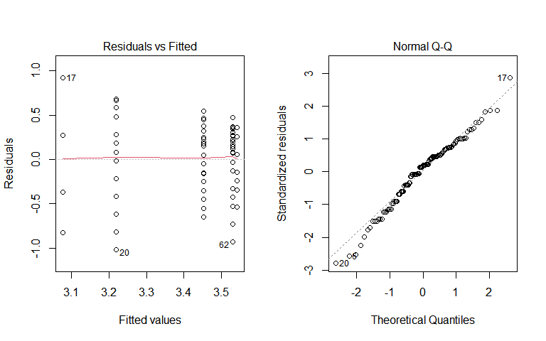

```r
par(mfrow=c(1,2))
plot(myaov.f, which=1:2)
```

Summary and assumptions from an anova for groups from mother’s education

```r
myaov.m <- aov(GPA ~ as.factor(mother_education), data = food.v)

pander(summary(myaov.m))
```

Analysis of Variance Model

|  | Df | Sum Sq | Mean Sq | F value | Pr(>F) |
| --- | --- | --- | --- | --- | --- |
| **as.factor(mother_education)** | 4 | 1.269 | 0.3172 | 2.161 | 0.07793 |
| **Residuals** | 112 | 16.43 | 0.1467 | NA | NA |

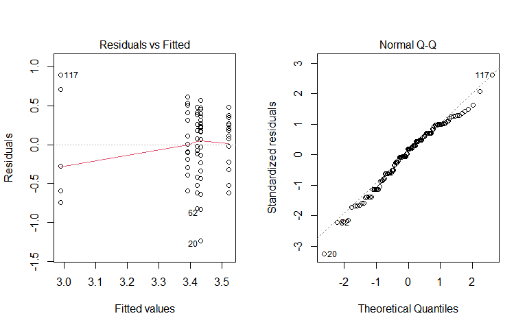

```r
par(mfrow=c(1,2))
plot(myaov.m, which=1:2)
```

**QQplots for individual**

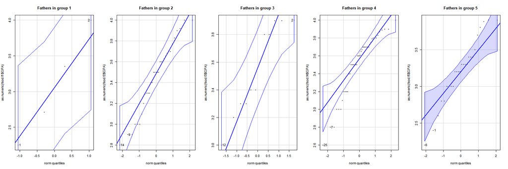

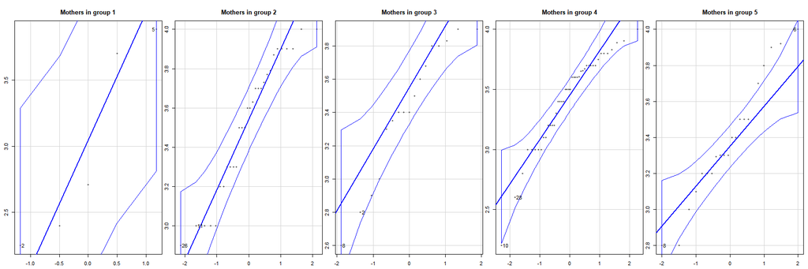

**Analysis**

From the tests above, we can find that some of the data in the mother distribution may be more disposed to not be normal. In general, because of the low sample in each group, and the unsurety of a normal distribution of data in each individual group, it will be safer to use a non-parametric test to test if at least one of the individual groups is unlikely to originate from a single distribution.

### Visualizing differences

**Visualizations Comparing data from education levels of the father**

```r
food.v["mother_education"][food.v["mother_education"] == '1'] <- "Less than HS"
food.v["mother_education"][food.v["mother_education"] == '2'] <- "HS Diploma"
food.v["mother_education"][food.v["mother_education"] == '3'] <- "Some College"
food.v["mother_education"][food.v["mother_education"] == '4'] <- "Bachelor's Degree"
food.v["mother_education"][food.v["mother_education"] == '5'] <- "Graduate Degree"

food.v <- food.v %>% mutate(mother_education=fct_relevel(mother_education,c("Less than HS","HS Diploma","Some College", "Bachelor's Degree", "Graduate Degree")))

food.v["father_education"][food.v["father_education"] == '1'] <- "Less than HS"
food.v["father_education"][food.v["father_education"] == '2'] <- "HS Diploma"
food.v["father_education"][food.v["father_education"] == '3'] <- "Some College"
food.v["father_education"][food.v["father_education"] == '4'] <- "Bachelor's Degree"
food.v["father_education"][food.v["father_education"] == '5'] <- "Graduate Degree"

food.v <- food.v %>% mutate(father_education=fct_relevel(father_education,c("Less than HS","HS Diploma","Some College", "Bachelor's Degree", "Graduate Degree")))
```

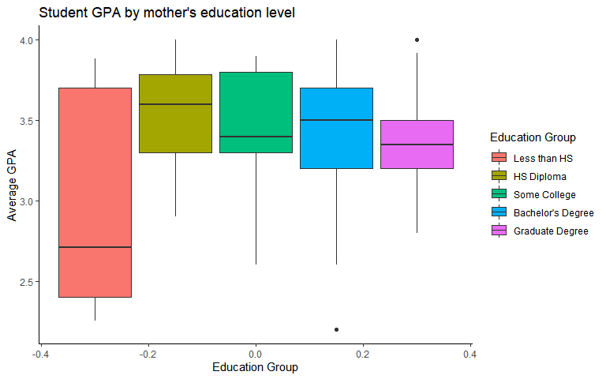

```r
ggplot(food.v , aes(y = as.numeric(GPA), fill = as.factor(mother_education))) +
geom_boxplot() +
  theme_classic() +
  labs(x = "Education Group",
       y = "Average GPA",
       title = "Student GPA by mother's education level"
       ) +
  guides(fill = guide_legend(title="Education Group"))
```

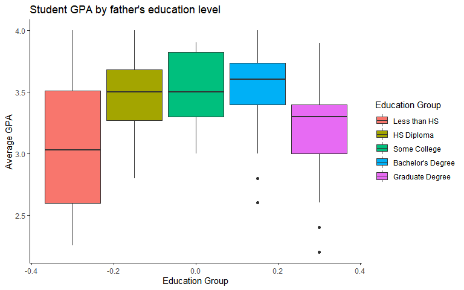

```r
ggplot(food.v , aes(y = as.numeric(GPA), fill = as.factor(father_education))) +
geom_boxplot() +
  theme_classic() +
  labs(x = "Education Group",
       y = "Average GPA",
       title = "Student GPA by father's education level"
       ) +
  guides(fill = guide_legend(title="Education Group"))
```

### Using a Kruskal-Wallis rank sum test

**Comparing data from education levels of the father**

```r
pander(kruskal.test(GPA ~ as.factor(father_education), data = food))
```

Kruskal-Wallis rank sum test: `GPA` by `as.factor(father_education)`

| Test statistic | df | P value |
| --- | --- | --- |
| 11.17 | 4 | 0.02472 * |

**Comparing data from education levels of the mother**

```r
pander(kruskal.test(GPA ~ as.factor(mother_education), data = food))
```

Kruskal-Wallis rank sum test: `GPA` by `as.factor(mother_education)`

| Test statistic | df | P value |
| --- | --- | --- |
| 3.781 | 4 | 0.4365 |

### Conclusion

According to the analysis assumptions, the null hypothesis of these analyses is that all of the GPA groups separated by parental education groups all come from the same distribution. The alternative hypothesis is that at least one of the GPA groups separated by parental education.

- The p-value for the father ANOVA is 0.004624*
- The p-value for the mother ANOVA is 0.07793
- The p-value for the father Kruskal Wallis is 0.02472*
- The p-value for the mother Kruskal Wallis is 0.4365

Since the analysis that tested to see if GPA of students according to father’s educational level reached a level of significance under both parametric and non-parametric assumptions from the ANOVA and Kruskal Wallis test respectively, we can, from this analysis reject the null hypothesis that GPA groups separated by father’s education come from the same distribution.

For the other tests, we cannot reject the null hypothesis.